# Credit Card Users Churn Prediction

- `Customer_Age` and `Months_on_book`have minimal impact on attrition.
- `Dependent_count` Customers with less dependents have comparatively more attrition.
- `Total_Relationship_Count`Customers with less number of products with bank have comparatively more attrition.
- `Months_Inactive_12_mon` Customers who are inactive for 2 to 3 months are more likely to attrite.
- `Contacts_Count_12_mon` Customer who contact 3 or more times are more likely to attrite.
- `Credit_Limit` Customers with less credit limit seem to attrite more compared to customers with higher credit limit.
- `Total_Revolving_Bal` Customers with low total revolving balance have more attrition.
- `Avg_Open_To_Buy` Customers with low average amount left on credit card to use have comparatively more attrition.
- `Total_Amt_Chng_Q4_Q1` Customers with low total amount changed between Q4 and Q1 more likely to attrite.
- `Total_Trans_Amt` Attrited customers have lower transactions amount and most transaction amounts range between $1000 and $3000.
- `Total_Trans_Ct` Attrited customers have lower transactions count and most transactions count range between 20 and 50.
- `Total_Ct_Chng_Q4_Q1` Customers with low transaction count changed between Q4 and Q1 more likely to attrite.
- `Avg_Utilization_Ratio` Customers with low average utilization ratio are more likely to attrite.
- Customers meeting the following conditions are at high-risk for attrition:
  - `Dependent_count` Less number of dependents.
  - `Total_Relationship_Count`Less number of products with the bank.
  - `Months_Inactive_12_mon` Inactive for 2 to 3 months.
  - `Contacts_Count_12_mon` 3 or more.
  - `Credit_Limit` Low credit limit.
  - `Total_Revolving_Bal` Low total revolving balance.
  - `Avg_Open_To_Buy` Low average amount left on credit card to use.
  - `Total_Amt_Chng_Q4_Q1` Low total amount changed between Q4 and Q1.
  - `Total_Trans_Amt` Lower transactions amount, ranging between $1000 and $3000.
  - `Total_Trans_Ct` Lower transactions count, ranging between 20 and 50.
  - `Total_Ct_Chng_Q4_Q1` Low transaction count change between Q4 and Q1.
  - `Avg_Utilization_Ratio` Lower average utilization ratio.

#### Attrition_Flag vs Categorical Features

```
Attrition_Flag  Attrited Customer  Existing Customer    All
Gender
All                          1627               8500  10127
F                             930               4428   5358
M                             697               4072   4769
------------------------------------------------------------------------------------------------------------------------
```

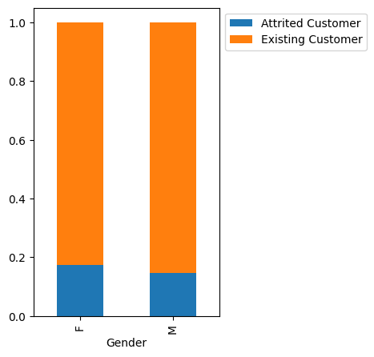

```
Attrition_Flag   Attrited Customer  Existing Customer    All
Education_Level
All                           1627               8500  10127
Graduate                       487               2641   3128
High School                    306               1707   2013
Missing                        256               1263   1519
Uneducated                     237               1250   1487
College                        154                859   1013
Doctorate                       95                356    451
Post-Graduate                   92                424    516
------------------------------------------------------------------------------------------------------------------------
```

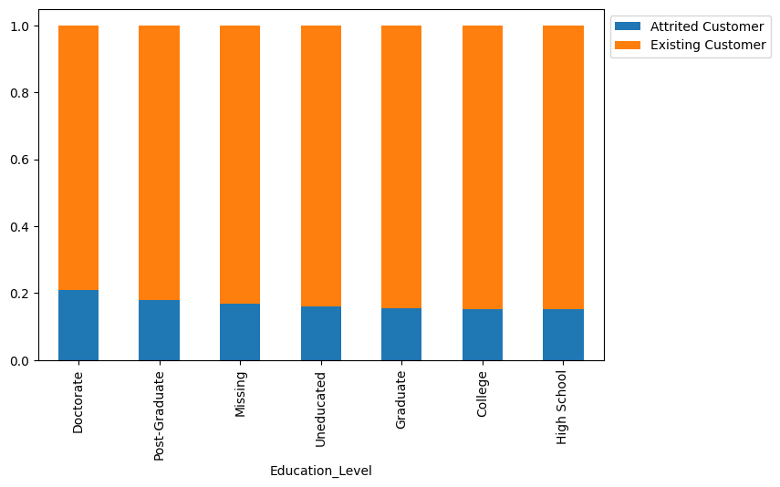

```
Attrition_Flag  Attrited Customer  Existing Customer    All
Marital_Status
All                          1627               8500  10127
Married                       709               3978   4687
Single                        668               3275   3943
Missing                       129                620    749
Divorced                      121                627    748
------------------------------------------------------------------------------------------------------------------------
```

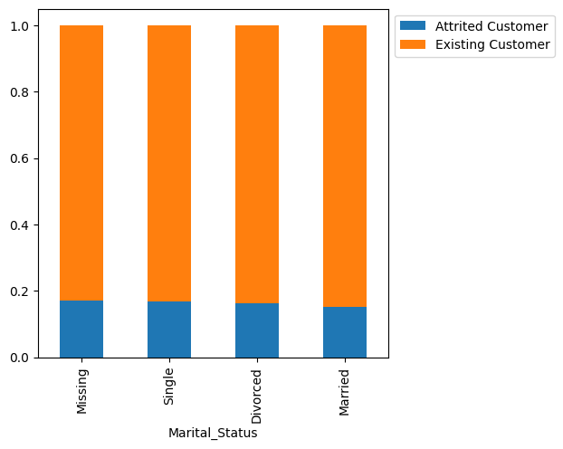

```
Attrition_Flag   Attrited Customer  Existing Customer    All
Income_Category
All                           1627               8500  10127
Less than $40K                 612               2949   3561
$40K - $60K                    271               1519   1790
$80K - $120K                   242               1293   1535
$60K - $80K                    189               1213   1402
abc                            187                925   1112
$120K +                        126                601    727
------------------------------------------------------------------------------------------------------------------------
```

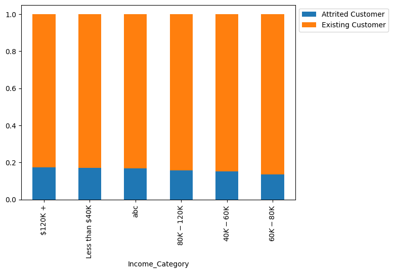

```
Attrition_Flag  Attrited Customer  Existing Customer    All
Card_Category
All                          1627               8500  10127
Blue                         1519               7917   9436
Silver                         82                473    555
Gold                           21                 95    116
Platinum                        5                 15     20
------------------------------------------------------------------------------------------------------------------------
```

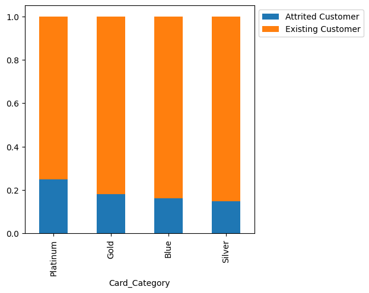

```python
# plotting the stacked bar plot for each categorical feature against Attrition Flag
for i, feature in enumerate(cat_features):
    stacked_barplot(data, feature,'Attrition_Flag')
```

- `Gender` Female customers have more attrition than male customers.
- `Education_Level` Customers with Doctorate have higher attrition followed by Post-Graduate customers. Customers with High School and College education have minimal attrition.
- `Marital_Status` Customers with missing marital status have higher attrition followed by "Single" customers.
- `Income_Category` Customers with income between $60k and $80K have mimimal attrition. Customers with income greater than $120k and less than $40K have comparatively more attrition.
- `Card_Category` Platinum customers have higher attrition followed by Gold customers.
- Customers meeting the following conditions are at high-risk for attrition:
  - `Gender` Female
  - `Education_Level` Doctorate or Post-Graduate
  - `Marital_Status` Missing or Single
  - `Income_Category` Less than $40K or greater than $120K
  - `Card_Category` Platinum or Gold

### Questions

**Questions**:

1. How is the total transaction amount distributed?
- `Total_Trans_Amt` distribution is right skewed.
- Average `Total_Trans_Amt` is 4404, and the range is between 510 and 18484.
2. What is the distribution of the level of education of customers?
- The distribution of the level of education of customers are listed below by frequency:
  - Graduate: 30.9% of the customers are Graduates.
  - High School: 19.9% of the customers are High School graduates.
  - Missing: 15% of the customers are missing education information in the dataset.
  - Uneducated: 14.7% of the customers are uneducated.
  - College: 10% of the customers are College graduates.
  - Post-Graduate: 5.1% of the customers are Post-graduates.
  - Doctorate: 4.5% of the customers have a Doctorate.
3. What is the distribution of the level of income of customers?
- The distribution of the level of income of customers is listed below by frequency:
  - Less than 40K: 35.2% of the customers have an income less than 40K.
  - 40K - 60K: 17.7% of the customers have an income between 40K and 60K.
  - 80K - 120K: 15.2% of the customers have an income between 80K and 120K.
  - 60K - 80K: 13.8% of the customers have an income between 60K and 80K.
  - abc: 11.0% of the customers have an unknown income range. These are misssing income information for the customers.
  - 120K+: 7.2% of the customers have an income greater than 120K.
4. How does the change in transaction amount between Q4 and Q1 (`total_ct_change_Q4_Q1`) vary by the customer's account status (`Attrition_Flag`)?
- Existing customers have a higher transaction count and Attrited customers mostly have a lower transaction count, between Q4 and Q1.
5. How does the number of months a customer was inactive in the last 12 months (`Months_Inactive_12_mon`) vary by the customer's account status (`Attrition_Flag`)?
- Existing customers have a wide range of inactivity (0-6 months). Most of the existing customers are inactive for 1, 2 or 3 months. And relatively a smaller set of existing customers have a longer period of inactivity.
- Attrited customers have a comparatively narrower range (1- 4 months), excluding outliers. Most of the attrited customers are inactive for 3 months, suggesting the customers tend to attrite after an inactive period of 3 months.
6. What are the attributes that have a strong correlation with each other?
- `Credit_Limit` and `Avg_Open_To_Buy` have a very strong positive correlation.
- `Total_Trans_Ct` and `Total_Trans_Amt` have a strong positive correlation.
- `Customer_Age` and `Months_on_book` have a strong positive correlation.
- `Avg_Utilization_Ratio` and `Total_Revolving_Bal` have a moderate positive correlation.
- `Total_Ct_Chang_Q4_Q1` and `Total_Amt_Chang_Q4_Q1` have a weak positive correlation.
- `Avg_Open_To_Buy` and `Credit_Limit` have a moderate negative correlation with `Avg_Utilization_Ratio`.
- `Total_Trans_Ct` and `Total_Trans_Amt` have a weak negative correlation with `Total_Relationship_Count`.

## Data Pre-processing

### Dropping Columns

- As `CLIENTNUM` is an unique identifier for each of the rows, dropping it from the data set.

```python
# Dropping 'CLIENTNUM' column from the data set for further analysis.
data.drop('CLIENTNUM', axis=1, inplace=True)
```

```python
# verify the first five rows
data.head(5)
```

|  | Attrition_Flag | Customer_Age | Gender | Dependent_count | Education_Level | Marital_Status | Income_Category | Card_Category | Months_on_book | Total_Relationship_Count | Months_Inactive_12_mon | Contacts_Count_12_mon | Credit_Limit | Total_Revolving_Bal | Avg_Open_To_Buy | Total_Amt_Chng_Q4_Q1 | Total_Trans_Amt | Total_Trans_Ct | Total_Ct_Chng_Q4_Q1 | Avg_Utilization_Ratio |
| --- | --- | --- | --- | --- | --- | --- | --- | --- | --- | --- | --- | --- | --- | --- | --- | --- | --- | --- | --- | --- |
| 0 | Existing Customer | 45 | M | 3 | High School | Married | $60K - $80K | Blue | 39 | 5 | 1 | 3 | 12691.0 | 777 | 11914.0 | 1.335 | 1144 | 42 | 1.625 | 0.061 |
| 1 | Existing Customer | 49 | F | 5 | Graduate | Single | Less than $40K | Blue | 44 | 6 | 1 | 2 | 8256.0 | 864 | 7392.0 | 1.541 | 1291 | 33 | 3.714 | 0.105 |
| 2 | Existing Customer | 51 | M | 3 | Graduate | Married | $80K - $120K | Blue | 36 | 4 | 1 | 0 | 3418.0 | 0 | 3418.0 | 2.594 | 1887 | 20 | 2.333 | 0.000 |
| 3 | Existing Customer | 40 | F | 4 | High School | Missing | Less than $40K | Blue | 34 | 3 | 4 | 1 | 3313.0 | 2517 | 796.0 | 1.405 | 1171 | 20 | 2.333 | 0.760 |
| 4 | Existing Customer | 40 | M | 3 | Uneducated | Married | $60K - $80K | Blue | 21 | 5 | 1 | 0 | 4716.0 | 0 | 4716.0 | 2.175 | 816 | 28 | 2.500 | 0.000 |

### Data Anomalies

- `Income_Category` has an unknown 'abc' category. This should be treated as missing information.

```python
# Replace 'abc' with NaN to be imputed during missing value treatment
data['Income_Category'] = data['Income_Category'].replace('abc', np.NaN)
```

- `Education_Level` and `Marital_Status`have missing values, that need to be imputed.

```python
impute_features = ['Education_Level', 'Marital_Status', 'Income_Category']

# Replace 'Missing' with NaN to be imputed during missing value treatment
data[impute_features] = data[impute_features].replace('Missing', np.nan)
```

### Outliers Treatment

```python
# find outliers for numerical features
# Calculate Q1, Q3, and IQR
Q1 = data[num_features].quantile(0.25)
Q3 = data[num_features].quantile(0.75)
IQR = Q3 - Q1

# Define lower and upper bounds
lower_bound = Q1 - 1.5 * IQR
upper_bound = Q3 + 1.5 * IQR

for i, col in enumerate(num_features):
  # Identify outliers
  outliers = data[(data[col] < lower_bound.loc[col]) | (data[col] > upper_bound.loc[col])]
  outlierCount = outliers[col].count()
  if outlierCount > 0:
    print(col, 'has', outlierCount, 'outliers')
    if(outliers[col].min()>upper_bound[col]):
      print("\tAll Outliers are in the upper bound")
      print("\tUpper Bound is",upper_bound[col])
      print("\tThe Outliers range between",outliers[col].min(),"and",outliers[col].max())
    elif(outliers[col].max()<lower_bound[col]):
      print("\tAll Outliers are in the lower bound")
      print("\tLower Bound is",lower_bound[col])
      print("\tThe Outliers range between",outliers[col].min(),"and",outliers[col].max())
    else:
      print("\tOutliers in both lower and upper bound")
      print("\tUpper Bound is",upper_bound[col])
      print("\tLower Bound is",lower_bound[col])
      print("\tThe Outliers range between",outliers[col].min(),"and",outliers[col].max())
  else:
    print(col, 'has no outliers')
```

```
Customer_Age has 2 outliers
	All Outliers are in the upper bound
	Upper Bound is 68.5
	The Outliers range between 70 and 73
Dependent_count has no outliers
Months_on_book has 386 outliers
	Outliers in both lower and upper bound
	Upper Bound is 53.5
	Lower Bound is 17.5
	The Outliers range between 13 and 56
Total_Relationship_Count has no outliers
Months_Inactive_12_mon has 331 outliers
	Outliers in both lower and upper bound
	Upper Bound is 4.5
	Lower Bound is 0.5
	The Outliers range between 0 and 6
Contacts_Count_12_mon has 629 outliers
	Outliers in both lower and upper bound
	Upper Bound is 4.5
	Lower Bound is 0.5
	The Outliers range between 0 and 6
Credit_Limit has 984 outliers
	All Outliers are in the upper bound
	Upper Bound is 23836.25
	The Outliers range between 23848.0 and 34516.0
Total_Revolving_Bal has no outliers
Avg_Open_To_Buy has 963 outliers
	All Outliers are in the upper bound
	Upper Bound is 22660.75
	The Outliers range between 22664.0 and 34516.0
Total_Amt_Chng_Q4_Q1 has 396 outliers
	Outliers in both lower and upper bound
	Upper Bound is 1.201
	Lower Bound is 0.28900000000000003
	The Outliers range between 0.0 and 3.397
Total_Trans_Amt has 896 outliers
	All Outliers are in the upper bound
	Upper Bound is 8619.25
	The Outliers range between 8620 and 18484
Total_Trans_Ct has 2 outliers
	All Outliers are in the upper bound
	Upper Bound is 135.0
	The Outliers range between 138 and 139
Total_Ct_Chng_Q4_Q1 has 394 outliers
	Outliers in both lower and upper bound
	Upper Bound is 1.172
	Lower Bound is 0.22799999999999998
	The Outliers range between 0.0 and 3.714
Avg_Utilization_Ratio has no outliers
```

**Outliers**

- `Customer_Age` (70-73), These are valid age range for senior citizens.
- `Months_on_book` (13-17 and 54-56), These are valid ranges for recent customers and long term customers with the bank.
- `Months_Inactive_12_mon` (0,5,6), These are valid number of months falling within 12 month period.
- `Contacts_Count_12_mon` (0,5,6), These are valid number of months falling within 12 month period.
- `Credit_Limit` (23848.0-34516.0), This is common for high earning customers to have a higher credit limit.
- `Avg_Open_To_Buy` (22664.0-34516.0), This is common for customers with high credit limit, who might have used a smaller portion of the available limit.
- `Total_Amt_Chng_Q4_Q1` (0-0.289 and 1.201-3.397), Customers tend to spend more or less compared to the last quarter. And the range seem to cover customers at the extreme end of both the cases. This is a valid data.
- `Total_Trans_Amt`(8620-18484), Some customers with higher credit limit might have a high transaction amount. This is a valid data.
- `Total_Trans_Ct` (138-139), Some customers might have large number of transactions corresponding to their large spending. This is a valid data.
- `Total_Ct_Chng_Q4_Q1` (0.0-0.227 and 1.172-3.714), This is in line with the pattern of `Total_Amt_Chng_Q4_Q1`, and should be valid.
- These outliers are contextually valid and represent distinct customer segments rather than anomalies. Hence the outliers need not be treated.

### Feature Engineering

- The target variable `Attrition_Flag` has string values, need to convert this to int

```python
# Replace 'Existing Customer' as 0 and 'Attrited Customer' as 1, in Attrition_Flag and convert the type to int
data['Attrition_Flag'] = data['Attrition_Flag'].replace({'Existing Customer': 0, 'Attrited Customer': 1})
data['Attrition_Flag'] = data['Attrition_Flag'].astype(int)
```

### Train Test Split

```python
# defining the explanatory (independent) and response (dependent) variables
X = data.drop(["Attrition_Flag"], axis=1)
y = data["Attrition_Flag"]
```

```python
# Splitting data into training, validation and test set:

# first we split data into 2 parts, say temporary and test (80:20)
X_temp, X_test, y_temp, y_test = train_test_split(X, y, test_size=0.2, random_state=1, stratify=y)

# then we split the temporary set into train and validation (80:20)
X_train, X_val, y_train, y_val = train_test_split(X_temp, y_temp, test_size=0.2, random_state=1, stratify=y_temp)

print(X_train.shape, X_val.shape, X_test.shape)
```

```
(6480, 19) (1621, 19) (2026, 19)
```

### Missing value imputation

`Education_Level`, `Marital_Status`, `Income_Category` have missing values, that need to be imputed.

```python
# Let's impute the missing values
imputer = SimpleImputer(missing_values=np.NaN, strategy='most_frequent')

# fit the imputer on train data and transform the train data
X_train[impute_features] = imputer.fit_transform(X_train[impute_features])

# transform the validation and test data using the imputer fit on train data
X_val[impute_features] = imputer.transform(X_val[impute_features])
X_test[impute_features] = imputer.transform(X_test[impute_features])
```

```python
# Checking class balance for whole data, train set, validation set, and test set

print("Target value ratio in y")
print(y.value_counts(1))
print("*" * 80)
print("Target value ratio in y_train")
print(y_train.value_counts(1))
print("*" * 80)
print("Target value ratio in y_val")
print(y_val.value_counts(1))
print("*" * 80)
print("Target value ratio in y_test")
print(y_test.value_counts(1))
print("*" * 80)
```

```
Target value ratio in y
Attrition_Flag
0    0.83934
1    0.16066
Name: proportion, dtype: float64
Target value ratio in y_train
Attrition_Flag
0    0.839352
1    0.160648
Name: proportion, dtype: float64
Target value ratio in y_val
Attrition_Flag
0    0.838988
1    0.161012
Name: proportion, dtype: float64
Target value ratio in y_test
Attrition_Flag
0    0.839585
1    0.160415
Name: proportion, dtype: float64
```

### Encoding Categorical features

```python
# creating dummy variables from training data
X_train = pd.get_dummies(X_train,drop_first=True)
X_train = X_train.astype(float)

# creating dummy variables from validation data
X_val = pd.get_dummies(X_val,drop_first=True)
X_val = X_val.astype(float)

# creating dummy variables from test data
X_test = pd.get_dummies(X_test,drop_first=True)
X_test = X_test.astype(float)

print(X_train.shape, X_val.shape, X_test.shape)
```

```
(6480, 29) (1621, 29) (2026, 29)
```

## Model Building

### Model evaluation criterion

**Which metric to optimize?**

**Let's define a function to output different metrics (including recall) on the train and test set.**

```python
# defining a function to compute different metrics to check performance of a classification model built using sklearn
def model_performance_classification_sklearn(model, predictors, target):
    """
    Function to compute different metrics to check classification model performance

    model: classifier
    predictors: independent variables
    target: dependent variable
    """

    # predicting using the independent variables
    pred = model.predict(predictors)

    acc = accuracy_score(target, pred)  # to compute Accuracy
    recall = recall_score(target, pred)  # to compute Recall
    precision = precision_score(target, pred)  # to compute Precision
    f1 = f1_score(target, pred)  # to compute F1-score

    # creating a dataframe of metrics
    df_perf = pd.DataFrame(
        {
            "Accuracy": acc,
            "Recall": recall,
            "Precision": precision,
            "F1": f1

        },
        index=[0],
    )

    return df_perf
```

### Model Building with original data

```python
# Create a data frame with columns Model, Data Type, Tuned, Training Recall Score, Validation Recall Score
model_performance_df = pd.DataFrame(columns=["Model", "Training Data Set", "Tuned", "Training Score", "Validation Score"])
```

```python
models = []  # Empty list to store all the models

modelsfit = []  # Empty list to store all the models after fitting

# Appending models into the list
models.append(("Bagging", BaggingClassifier(random_state=1)))
models.append(("Random forest", RandomForestClassifier(random_state=1)))
## Complete the code to append remaining 3 models in the list models
models.append(("Decision tree", DecisionTreeClassifier(random_state=1)))
models.append(("AdaBoost", AdaBoostClassifier(random_state=1)))
models.append(("Gradient Boosting", GradientBoostingClassifier(random_state=1)))
# Append the optional XGBoost model
models.append(("XGBoost", XGBClassifier(random_state=1)))

print("\n" "Training Performance:" "\n")
for name, model in models:
    model.fit(X_train, y_train)
    scores = recall_score(y_train, model.predict(X_train))
    print("{}: {}".format(name, scores))
    modelsfit.append((name,model))
    # Append the scores
    model_performance_df = pd.concat([model_performance_df, pd.DataFrame([{"Model": name, "Training Data Set": "Original", "Tuned": "No", "Training Score": scores}])], ignore_index=True)

# Create a temporary DataFrame to store validation scores
val_scores_df = pd.DataFrame(columns=['Model', 'Data Type','Validation Score'])

print("\n" "Validation Performance:" "\n")



#for name, model in models:
for name, model in modelsfit:
    scores_val = recall_score(y_val, model.predict(X_val))
    print("{}: {}".format(name, scores_val))
   # Append validation scores to the temporary DataFrame
    val_scores_df = pd.concat([val_scores_df, pd.DataFrame([{'Model': name, "Training Data Set": "Original",'Validation Score': scores_val}])], ignore_index=True)

# Create a dictionary of Validation Scores with (Model, Data Type) as tuple key
val_scores_dict = {}
for index in val_scores_df.index:
    val_scores_dict[tuple(val_scores_df.loc[index, ['Model', 'Training Data Set']])] = val_scores_df.loc[index, 'Validation Score']

# Update 'Validation Score' column in model_performance_df using the tuple key, only if NaN
model_performance_df['Validation Score'] = model_performance_df.apply(
    lambda row: val_scores_dict.get(tuple(row[['Model', 'Training Data Set']])) if pd.isnull(row['Validation Score']) else row['Validation Score'],
    axis=1
)
```

```
Training Performance:

Bagging: 0.9769452449567724
Random forest: 1.0
Decision tree: 1.0
AdaBoost: 0.8443804034582133
Gradient Boosting: 0.8789625360230547
XGBoost: 1.0

Validation Performance:

Bagging: 0.8160919540229885
Random forest: 0.8007662835249042
Decision tree: 0.8314176245210728
AdaBoost: 0.842911877394636
Gradient Boosting: 0.8735632183908046
XGBoost: 0.89272030651341
```

```python
model_performance_df['Difference'] = model_performance_df['Training Score'] - model_performance_df['Validation Score']
model_performance_df[model_performance_df['Training Data Set'] == 'Original']
```

|  | Model | Training Data Set | Tuned | Training Score | Validation Score | Difference |
| --- | --- | --- | --- | --- | --- | --- |
| 0 | Bagging | Original | No | 0.976945 | 0.816092 | 0.160853 |
| 1 | Random forest | Original | No | 1.000000 | 0.800766 | 0.199234 |
| 2 | Decision tree | Original | No | 1.000000 | 0.831418 | 0.168582 |
| 3 | AdaBoost | Original | No | 0.844380 | 0.842912 | 0.001469 |
| 4 | Gradient Boosting | Original | No | 0.878963 | 0.873563 | 0.005399 |
| 5 | XGBoost | Original | No | 1.000000 | 0.892720 | 0.107280 |

- Gradient Boosting is the best performing model, with minimal overfitting
  - High Validation Score (0.8736)
  - Low difference (.0054)
- It is followed by AdaBoost
  - High Validation Score (0.8429), slightly lower than Gradient Boosting.
  - Smallest Difference (.0015)
- XGBoost has the highest validation score of all, but it has a significant difference between training and validation scores, indicating overfitting.

### Model Building with Oversampled data

```python
# Synthetic Minority Over Sampling Technique
sm = SMOTE(sampling_strategy=1, k_neighbors=5, random_state=1)
X_train_over, y_train_over = sm.fit_resample(X_train, y_train)
```

```python
print("Before OverSampling, count of label '1': {}".format(sum(y_train == 1)))
print("Before OverSampling, count of label '0': {} \n".format(sum(y_train == 0)))

print("After OverSampling, count of label '1': {}".format(sum(y_train_over == 1)))
print("After OverSampling, count of label '0': {} \n".format(sum(y_train_over == 0)))

print("After OverSampling, the shape of train_X: {}".format(X_train_over.shape))
print("After OverSampling, the shape of train_y: {} \n".format(y_train_over.shape))
```

```
Before OverSampling, count of label '1': 1041
Before OverSampling, count of label '0': 5439

After OverSampling, count of label '1': 5439
After OverSampling, count of label '0': 5439

After OverSampling, the shape of train_X: (10878, 29)
After OverSampling, the shape of train_y: (10878,)
```

```python
models_oversampled = []  # Empty list to store all the models for oversampled data
modelsfit_oversampled = []  # Empty list to store all the models after fitting

# Appending 5 models into the list
models_oversampled.append(("Bagging", BaggingClassifier(random_state=1)))
models_oversampled.append(("Random forest", RandomForestClassifier(random_state=1)))
models_oversampled.append(("Decision tree", DecisionTreeClassifier(random_state=1)))
models_oversampled.append(("AdaBoost", AdaBoostClassifier(random_state=1)))
models_oversampled.append(("Gradient Boosting", GradientBoostingClassifier(random_state=1)))
# Append the optional XGBoost model
models_oversampled.append(("XGBoost", XGBClassifier(random_state=1)))


print("\n" "Training Performance:" "\n")
for name, model_os in models_oversampled:
    model_os.fit(X_train_over, y_train_over)
    scores = recall_score(y_train_over, model_os.predict(X_train_over))
    print("{}: {}".format(name, scores))
    modelsfit_oversampled.append((name,model_os))
    # Append the scores
    model_performance_df = pd.concat([model_performance_df, pd.DataFrame([{"Model": name, "Training Data Set": "Over Sampled", "Tuned": "No", "Training Score": scores}])], ignore_index=True)

# Create a temporary DataFrame to store validation scores
val_scores_df = pd.DataFrame(columns=['Model', 'Training Data Set','Validation Score'])

print("\n" "Validation Performance:" "\n")

for name, model_os in modelsfit_oversampled:
    scores_val = recall_score(y_val, model_os.predict(X_val))
    print("{}: {}".format(name, scores_val))
    # Append validation scores to the temporary DataFrame
    val_scores_df = pd.concat([val_scores_df, pd.DataFrame([{'Model': name, "Training Data Set": "Over Sampled",'Validation Score': scores_val}])], ignore_index=True)

# Create a dictionary of Validation Scores with (Model, Data Type) as tuple key
val_scores_dict = {}
for index in val_scores_df.index:
    val_scores_dict[tuple(val_scores_df.loc[index, ['Model', 'Training Data Set']])] = val_scores_df.loc[index, 'Validation Score']

# Update 'Validation Score' column in model_performance_df using the tuple key, only if NaN
model_performance_df['Validation Score'] = model_performance_df.apply(
    lambda row: val_scores_dict.get(tuple(row[['Model', 'Training Data Set']])) if pd.isnull(row['Validation Score']) else row['Validation Score'],
    axis=1
)
```

```
Training Performance:

Bagging: 0.9985291413862842
Random forest: 1.0
Decision tree: 1.0
AdaBoost: 0.9687442544585402
Gradient Boosting: 0.9810626953484096
XGBoost: 1.0

Validation Performance:

Bagging: 0.8467432950191571
Random forest: 0.8007662835249042
Decision tree: 0.8314176245210728
AdaBoost: 0.8659003831417624
Gradient Boosting: 0.8812260536398467
XGBoost: 0.9042145593869731
```

```python
model_performance_df['Difference'] = model_performance_df['Training Score'] - model_performance_df['Validation Score']
model_performance_df[model_performance_df['Training Data Set'] == 'Over Sampled']
```

|  | Model | Training Data Set | Tuned | Training Score | Validation Score | Difference |
| --- | --- | --- | --- | --- | --- | --- |
| 6 | Bagging | Over Sampled | No | 0.998529 | 0.846743 | 0.151786 |
| 7 | Random forest | Over Sampled | No | 1.000000 | 0.800766 | 0.199234 |
| 8 | Decision tree | Over Sampled | No | 1.000000 | 0.831418 | 0.168582 |
| 9 | AdaBoost | Over Sampled | No | 0.968744 | 0.865900 | 0.102844 |
| 10 | Gradient Boosting | Over Sampled | No | 0.981063 | 0.881226 | 0.099837 |
| 11 | XGBoost | Over Sampled | No | 1.000000 | 0.904215 | 0.095785 |

- XGBoost is the best performing model, with minimal overfitting
  - Highest Validation Score (0.9042)
  - Lowest difference (.0958)
- It is followed by Gradient Boosting
  - High Validation Score (0.8812), slightly lower than XGBoost.
  - Low Difference (.0998), slighly higher than XGBoost

### Model Building with Undersampled data

```python
# Random undersampler for under sampling the data
rus = RandomUnderSampler(random_state=1, sampling_strategy=1)
X_train_un, y_train_un = rus.fit_resample(X_train, y_train)
```

```python
print("Before Under Sampling, count of label '1': {}".format(sum(y_train == 1)))
print("Before Under Sampling, count of label '0': {} \n".format(sum(y_train == 0)))

print("After Under Sampling, count of label '1': {}".format(sum(y_train_un == 1)))
print("After Under Sampling, count of label '0': {} \n".format(sum(y_train_un == 0)))

print("After Under Sampling, the shape of train_X: {}".format(X_train_un.shape))
print("After Under Sampling, the shape of train_y: {} \n".format(y_train_un.shape))
```

```
Before Under Sampling, count of label '1': 1041
Before Under Sampling, count of label '0': 5439

After Under Sampling, count of label '1': 1041
After Under Sampling, count of label '0': 1041

After Under Sampling, the shape of train_X: (2082, 29)
After Under Sampling, the shape of train_y: (2082,)
```

```python
models_undersampled = []  # Empty list to store all the models for under sampled data
modelsfit_undersampled = []  # Empty list to store all the models after fitting

# Appending 5 models into the list
models_undersampled.append(("Bagging", BaggingClassifier(random_state=1)))
models_undersampled.append(("Random forest", RandomForestClassifier(random_state=1)))
models_undersampled.append(("Decision tree", DecisionTreeClassifier(random_state=1)))
models_undersampled.append(("AdaBoost", AdaBoostClassifier(random_state=1)))
models_undersampled.append(("Gradient Boosting", GradientBoostingClassifier(random_state=1)))
# Append the optional XGBoost model
models_undersampled.append(("XGBoost", XGBClassifier(random_state=1)))


print("\n" "Training Performance:" "\n")
for name, model_un in models_undersampled:
    model_un.fit(X_train_un, y_train_un)
    scores = recall_score(y_train_un, model_un.predict(X_train_un))
    print("{}: {}".format(name, scores))
    modelsfit_undersampled.append((name,model_un))
    # Append the scores
    model_performance_df = pd.concat([model_performance_df, pd.DataFrame([{"Model": name, "Training Data Set": "Under Sampled", "Tuned": "No", "Training Score": scores}])], ignore_index=True)

# Create a temporary DataFrame to store validation scores
val_scores_df = pd.DataFrame(columns=['Model', 'Training Data Set','Validation Score'])

print("\n" "Validation Performance:" "\n")

for name, model_un in modelsfit_undersampled:
    scores_val = recall_score(y_val, model_un.predict(X_val))
    print("{}: {}".format(name, scores_val))
    # Append validation scores to the temporary DataFrame
    val_scores_df = pd.concat([val_scores_df, pd.DataFrame([{'Model': name, "Training Data Set": "Under Sampled",'Validation Score': scores_val}])], ignore_index=True)

# Create a dictionary of Validation Scores with (Model, Data Type) as tuple key
val_scores_dict = {}
for index in val_scores_df.index:
    val_scores_dict[tuple(val_scores_df.loc[index, ['Model', 'Training Data Set']])] = val_scores_df.loc[index, 'Validation Score']

# Update 'Validation Score' column in model_performance_df using the tuple key, only if NaN
model_performance_df['Validation Score'] = model_performance_df.apply(
    lambda row: val_scores_dict.get(tuple(row[['Model', 'Training Data Set']])) if pd.isnull(row['Validation Score']) else row['Validation Score'],
    axis=1
)
```

```
Training Performance:

Bagging: 0.9951969260326609
Random forest: 1.0
Decision tree: 1.0
AdaBoost: 0.9567723342939481
Gradient Boosting: 0.9865513928914506
XGBoost: 1.0

Validation Performance:

Bagging: 0.9386973180076629
Random forest: 0.9578544061302682
Decision tree: 0.89272030651341
AdaBoost: 0.9540229885057471
Gradient Boosting: 0.9540229885057471
XGBoost: 0.9693486590038314
```

```python
model_performance_df['Difference'] = model_performance_df['Training Score'] - model_performance_df['Validation Score']
model_performance_df[model_performance_df['Training Data Set'] == 'Under Sampled']
```

|  | Model | Training Data Set | Tuned | Training Score | Validation Score | Difference |
| --- | --- | --- | --- | --- | --- | --- |
| 12 | Bagging | Under Sampled | No | 0.995197 | 0.938697 | 0.056500 |
| 13 | Random forest | Under Sampled | No | 1.000000 | 0.957854 | 0.042146 |
| 14 | Decision tree | Under Sampled | No | 1.000000 | 0.892720 | 0.107280 |
| 15 | AdaBoost | Under Sampled | No | 0.956772 | 0.954023 | 0.002749 |
| 16 | Gradient Boosting | Under Sampled | No | 0.986551 | 0.954023 | 0.032528 |
| 17 | XGBoost | Under Sampled | No | 1.000000 | 0.969349 | 0.030651 |

- XGBoost is the best performing model, with minimal overfitting
  - Highest Validation Score (0.9693)
  - Low difference (.0307)
- It is followed by Random Forest
  - High Validation Score (0.9579), slightly lower than XGBoost.
  - Low Difference (.0421), slighly higher than XGBoost
- AdaBoost though its thrid best model by validation score, seems to be a more stable model with lowest difference (.0027)

### Top Models

```python
# Sort the DataFrame by 'Validation Score' in descending order
model_performance_df = model_performance_df.sort_values(by='Validation Score', ascending=False)
# Reset the index
model_performance_df = model_performance_df.reset_index(drop=True)
# Add 1 to the index to start it from 1 instead of 0
model_performance_df.index += 1

model_performance_df
```

|  | Model | Training Data Set | Tuned | Training Score | Validation Score | Difference |
| --- | --- | --- | --- | --- | --- | --- |
| 1 | XGBoost | Under Sampled | No | 1.000000 | 0.969349 | 0.030651 |
| 2 | Random forest | Under Sampled | No | 1.000000 | 0.957854 | 0.042146 |
| 3 | Gradient Boosting | Under Sampled | No | 0.986551 | 0.954023 | 0.032528 |
| 4 | AdaBoost | Under Sampled | No | 0.956772 | 0.954023 | 0.002749 |
| 5 | Bagging | Under Sampled | No | 0.995197 | 0.938697 | 0.056500 |
| 6 | XGBoost | Over Sampled | No | 1.000000 | 0.904215 | 0.095785 |
| 7 | XGBoost | Original | No | 1.000000 | 0.892720 | 0.107280 |
| 8 | Decision tree | Under Sampled | No | 1.000000 | 0.892720 | 0.107280 |
| 9 | Gradient Boosting | Over Sampled | No | 0.981063 | 0.881226 | 0.099837 |
| 10 | Gradient Boosting | Original | No | 0.878963 | 0.873563 | 0.005399 |
| 11 | AdaBoost | Over Sampled | No | 0.968744 | 0.865900 | 0.102844 |
| 12 | Bagging | Over Sampled | No | 0.998529 | 0.846743 | 0.151786 |
| 13 | AdaBoost | Original | No | 0.844380 | 0.842912 | 0.001469 |
| 14 | Decision tree | Over Sampled | No | 1.000000 | 0.831418 | 0.168582 |
| 15 | Decision tree | Original | No | 1.000000 | 0.831418 | 0.168582 |
| 16 | Bagging | Original | No | 0.976945 | 0.816092 | 0.160853 |
| 17 | Random forest | Original | No | 1.000000 | 0.800766 | 0.199234 |
| 18 | Random forest | Over Sampled | No | 1.000000 | 0.800766 | 0.199234 |

- After building 18 models, it was observed that most of the models trained on an undersampled dataset exhibited strong performance on both the training and validation datasets.
- XGBoost model trained in undersampled data has the highest validation score, and second lowest difference among the top 5 models with best validation score. This is the top performing model.
- Random Forest, Gradient Boosting and AdaBoost models trained in undersampled data has more or less the same validation score. Considering the difference for these models, the next best model is AdaBoost followed by Gradient Boosting.
- We will tune the below 3 models using the same data (undersampled) as we trained them on before
  - XGBoost
  - AdaBoost
  - Gradient Boosting

### HyperparameterTuning

#### Tuning of XGBoost with undersampled data

```python
%%time

name = 'XGBoost'
dataset = 'Under Sampled'
# defining model
XGB_Un_Tuned = XGBClassifier(random_state=1)

# Parameter grid to pass in RandomSearchCV
param_grid = {'n_estimators':np.arange(50,110,25),
            'scale_pos_weight':[1,2,5],
            'learning_rate':[0.01,0.1,0.05],
            'gamma':[1,3],
            'subsample':[0.7,0.9]}

scorer = metrics.make_scorer(metrics.recall_score)

#Calling RandomizedSearchCV
randomized_cv = RandomizedSearchCV(estimator=XGB_Un_Tuned, param_distributions=param_grid, n_iter=10, n_jobs = -1, scoring=scorer, cv=5, random_state=1)

#Fitting parameters in RandomizedSearchCV
randomized_cv.fit(X_train_un,y_train_un)

print("Best parameters are {} with CV score={}:" .format(randomized_cv.best_params_,randomized_cv.best_score_))
```

```
Best parameters are {'subsample': 0.7, 'scale_pos_weight': 5, 'n_estimators': 75, 'learning_rate': 0.05, 'gamma': 3} with CV score=0.9836768494663233:
CPU times: user 1.74 s, sys: 158 ms, total: 1.9 s
Wall time: 39.7 s
```

```python
#Build XGBoost model with best parameters
xgb1_tuned = XGBClassifier(n_estimators = 75,
                                    subsample = 0.7,
                                    scale_pos_weight = 5,
                                    learning_rate = 0.05,
                                    gamma = 3,
                                    random_state=1)
xgb1_tuned.fit(X_train_un,y_train_un)
```

```
XGBClassifier(base_score=0.5, booster='gbtree', callbacks=None,
              colsample_bylevel=1, colsample_bynode=1, colsample_bytree=1,
              early_stopping_rounds=None, enable_categorical=False,
              eval_metric=None, gamma=3, gpu_id=-1, grow_policy='depthwise',
              importance_type=None, interaction_constraints='',
              learning_rate=0.05, max_bin=256, max_cat_to_onehot=4,
              max_delta_step=0, max_depth=6, max_leaves=0, min_child_weight=1,
              missing=nan, monotone_constraints='()', n_estimators=75, n_jobs=0,
              num_parallel_tree=1, predictor='auto', random_state=1,
              reg_alpha=0, reg_lambda=1, ...)
```

```python
print("\n" "Training Performance:" "\n")
scores = recall_score(y_train_un, xgb1_tuned.predict(X_train_un))
print("{}: {}".format(name, scores))

print("\n" "Validation Performance:" "\n")
scores_val = recall_score(y_val, xgb1_tuned.predict(X_val))
print("{}: {}".format(name, scores_val))
# Append the scores
model_performance_df = pd.concat([model_performance_df, pd.DataFrame([{"Model": name, "Training Data Set": dataset, "Tuned": "Yes", "Training Score": scores,"Validation Score":scores_val }])], ignore_index=True)
```

```
Training Performance:

XGBoost: 1.0

Validation Performance:

XGBoost: 0.9885057471264368
```

```python
# Checking model's performance on training set
xgb_train = model_performance_classification_sklearn(xgb1_tuned,X_train_un,y_train_un)
xgb_train
```

|  | Accuracy | Recall | Precision | F1 |
| --- | --- | --- | --- | --- |
| 0 | 0.963016 | 1.0 | 0.931127 | 0.964335 |

```python
# Checking model's performance on validation set
xgb_val = model_performance_classification_sklearn(xgb1_tuned,X_val,y_val)
xgb_val
```

|  | Accuracy | Recall | Precision | F1 |
| --- | --- | --- | --- | --- |
| 0 | 0.895126 | 0.988506 | 0.607059 | 0.752187 |

#### Tuning of AdaBoost with undersampled data

```python
%%time

name = 'AdaBoost'
dataset = 'Under Sampled'
# defining model
abc1 = AdaBoostClassifier(random_state=1)

# Parameter grid to pass in RandomSearchCV
param_grid = {"n_estimators": np.arange(50,110,25),
              "learning_rate": [0.01,0.1,0.05],
              "estimator": [
                                  DecisionTreeClassifier(max_depth=2, random_state=1),
                                  DecisionTreeClassifier(max_depth=3, random_state=1),
                                ],}

#Calling RandomizedSearchCV
randomized_cv = RandomizedSearchCV(estimator=abc1, param_distributions=param_grid, n_iter=10, n_jobs = -1, scoring=scorer, cv=5, random_state=1)

#Fitting parameters in RandomizedSearchCV
randomized_cv.fit(X_train_un,y_train_un)

print("Best parameters are {} with CV score={}:" .format(randomized_cv.best_params_,randomized_cv.best_score_))
```

```
Best parameters are {'n_estimators': 100, 'learning_rate': 0.1, 'estimator': DecisionTreeClassifier(max_depth=3, random_state=1)} with CV score=0.9500644092749356:
CPU times: user 2.08 s, sys: 52.7 ms, total: 2.13 s
Wall time: 30 s
```

```python
#Build AdaBoost model with best parameters
abc1_tuned = AdaBoostClassifier(n_estimators = 100,
                                   learning_rate = 0.1,
                                   estimator = DecisionTreeClassifier(max_depth=3, random_state=1),
                                   random_state=1)
abc1_tuned.fit(X_train_un,y_train_un)
```

```
AdaBoostClassifier(estimator=DecisionTreeClassifier(max_depth=3,
                                                    random_state=1),
                   learning_rate=0.1, n_estimators=100, random_state=1)
```

```python
print("\n" "Training Performance:" "\n")
scores = recall_score(y_train_un, abc1_tuned.predict(X_train_un))
print("{}: {}".format(name, scores))

print("\n" "Validation Performance:" "\n")
scores_val = recall_score(y_val, abc1_tuned.predict(X_val))
print("{}: {}".format(name, scores_val))
# Append the scores
model_performance_df = pd.concat([model_performance_df, pd.DataFrame([{"Model": name, "Training Data Set": dataset, "Tuned": "Yes", "Training Score": scores,"Validation Score":scores_val }])], ignore_index=True)
```

```
Training Performance:

AdaBoost: 0.9932756964457252

Validation Performance:

AdaBoost: 0.9540229885057471
```

```python
# Checking model's performance on training set
abc_train = model_performance_classification_sklearn(abc1_tuned,X_train_un,y_train_un)
abc_train
```

|  | Accuracy | Recall | Precision | F1 |
| --- | --- | --- | --- | --- |
| 0 | 0.990394 | 0.993276 | 0.987584 | 0.990421 |

```python
# Checking model's performance on validation set
abc_val = model_performance_classification_sklearn(abc1_tuned,X_val,y_val)
abc_val
```

|  | Accuracy | Recall | Precision | F1 |
| --- | --- | --- | --- | --- |
| 0 | 0.940777 | 0.954023 | 0.747748 | 0.838384 |

#### Tuning of Gradient Boosting with undersampled data

```python
%%time

name = 'Gradient Boosting'
dataset = 'Under Sampled'
# defining model
gb1 = GradientBoostingClassifier(random_state=1)

# Parameter grid to pass in RandomSearchCV
param_grid = { "init": [AdaBoostClassifier(random_state=1),DecisionTreeClassifier(random_state=1)],
              "n_estimators": np.arange(50,110,25),
              "learning_rate": [0.01,0.1,0.05],
              "subsample":[0.7,0.9],
              "max_features":[0.5,0.7,1], }

#Calling RandomizedSearchCV
randomized_cv = RandomizedSearchCV(estimator=gb1, param_distributions=param_grid, n_iter=10, n_jobs = -1, scoring=scorer, cv=5, random_state=1)

#Fitting parameters in RandomizedSearchCV
randomized_cv.fit(X_train_un,y_train_un)

print("Best parameters are {} with CV score={}:" .format(randomized_cv.best_params_,randomized_cv.best_score_))
```

```
Best parameters are {'subsample': 0.7, 'n_estimators': 100, 'max_features': 0.7, 'learning_rate': 0.05, 'init': DecisionTreeClassifier(random_state=1)} with CV score=0.8943365844681634:
CPU times: user 885 ms, sys: 32.1 ms, total: 917 ms
Wall time: 13.1 s
```

```python
#Build Gradient Boosting model with best parameters
gb1_tuned = GradientBoostingClassifier(subsample = 0.7,
                                       n_estimators = 100,
                                       max_features = 0.7,
                                       learning_rate = 0.05,
                                       init = DecisionTreeClassifier(random_state=1),
                                       random_state=1)
gb1_tuned.fit(X_train_un,y_train_un)
```

```
GradientBoostingClassifier(init=DecisionTreeClassifier(random_state=1),
                           learning_rate=0.05, max_features=0.7, random_state=1,
                           subsample=0.7)
```

```python
print("\n" "Training Performance:" "\n")
scores = recall_score(y_train_un, gb1_tuned.predict(X_train_un))
print("{}: {}".format(name, scores))

print("\n" "Validation Performance:" "\n")
scores_val = recall_score(y_val, gb1_tuned.predict(X_val))
print("{}: {}".format(name, scores_val))
# Append the scores
model_performance_df = pd.concat([model_performance_df, pd.DataFrame([{"Model": name, "Training Data Set": dataset, "Tuned": "Yes", "Training Score": scores,"Validation Score":scores_val }])], ignore_index=True)
```

```
Training Performance:

Gradient Boosting: 1.0

Validation Performance:

Gradient Boosting: 0.89272030651341
```

```python
# Checking model's performance on training set
gb_train = model_performance_classification_sklearn(gb1_tuned,X_train_un,y_train_un)
gb_train
```

|  | Accuracy | Recall | Precision | F1 |
| --- | --- | --- | --- | --- |
| 0 | 1.0 | 1.0 | 1.0 | 1.0 |

```python
# Checking model's performance on validation set
gb_val = model_performance_classification_sklearn(gb1_tuned,X_val,y_val)
gb_val
```

|  | Accuracy | Recall | Precision | F1 |
| --- | --- | --- | --- | --- |
| 0 | 0.899445 | 0.89272 | 0.633152 | 0.740859 |

## Model Comparison and Final Model Selection

```python
# training performance comparison

models_train_comp_df = pd.concat(
    [
        xgb_train.T,
        abc_train.T,
        gb_train.T,
    ],
    axis=1,
)
models_train_comp_df.columns = [
    "XGBoost trained with Undersampled data",
    "AdaBoost trained with Undersampled data",
    "GradientBossting trained with Undersampled data",
]
print("Training performance comparison:")
models_train_comp_df
```

```
Training performance comparison:
```

|  | XGBoost trained with Undersampled data | AdaBoost trained with Undersampled data | GradientBossting trained with Undersampled data |
| --- | --- | --- | --- |
| Accuracy | 0.963016 | 0.990394 | 1.0 |
| Recall | 1.000000 | 0.993276 | 1.0 |
| Precision | 0.931127 | 0.987584 | 1.0 |
| F1 | 0.964335 | 0.990421 | 1.0 |

```python
# Validation performance comparison

models_val_comp_df = pd.concat(
    [ xgb_val.T, abc_val.T, gb_val.T], axis=1,
)
models_val_comp_df.columns = [
    "XGBoost trained with Undersampled data",
    "AdaBoost trained with Undersampled data",
    "GradientBossting trained with Undersampled data",
]
print("Validation performance comparison:")
models_val_comp_df
```

```
Validation performance comparison:
```

|  | XGBoost trained with Undersampled data | AdaBoost trained with Undersampled data | GradientBossting trained with Undersampled data |
| --- | --- | --- | --- |
| Accuracy | 0.895126 | 0.940777 | 0.899445 |
| Recall | 0.988506 | 0.954023 | 0.892720 |
| Precision | 0.607059 | 0.747748 | 0.633152 |
| F1 | 0.752187 | 0.838384 | 0.740859 |

- XGBoost has the best recall, but its precision is weak.
- AdaBoost is the best performer overall, with the highest accuracy (94%), strong precision (75%), and a well-balanced F1-score (83.8%).
- Gradient Boosting has a lower recall than the other two.
- As maximizing recall is our priority, XGBoost is the best choice. It achieves 98.85% recall.

### Test set final performance

```python
# Let's check the performance on test set
xgb_test = model_performance_classification_sklearn(xgb1_tuned, X_test, y_test)
xgb_test
```

|  | Accuracy | Recall | Precision | F1 |
| --- | --- | --- | --- | --- |
| 0 | 0.881046 | 0.990769 | 0.575 | 0.727684 |

- XGBoost model trained on undersampled data has given 99% recall on the test set
- This performance is in line with what we achieved with this model on the train and validation sets
- This is the best model for our need.

#### Feature Importance

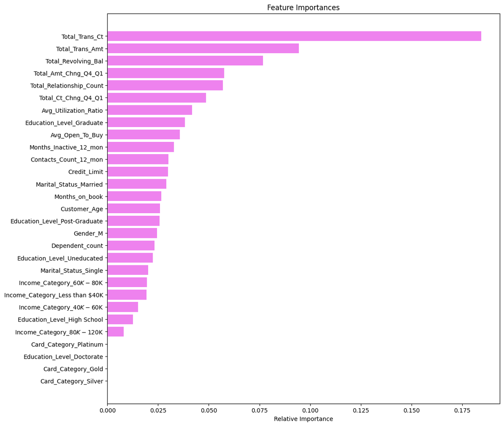

```python
feature_names = X_train.columns
importances = xgb1_tuned.feature_importances_
indices = np.argsort(importances)

plt.figure(figsize=(12, 12))
plt.title("Feature Importances")
plt.barh(range(len(indices)), importances[indices], color="violet", align="center")
plt.yticks(range(len(indices)), [feature_names[i] for i in indices])
plt.xlabel("Relative Importance")
plt.show()
```

- Top 5 most important features for making predictions are
  1. Total_Trans_Ct
  2. Total_Trans_Amt
  3. Total_Revolving_Bal
  4. Total_Amt_Chng_Q4_Q1
  5. Total_Relationship_Count

# Business Insights and Conclusions

**Business Insights**

- Customers with the following behaviors are more likely to attrite:
  - **Low Engagement & Financial Activity:**
    - Low Transaction Volume: 20-50 transactions annually.
    - Reduced Spending: Transaction amounts between 1,000 and 3,000 annually.
    - Limited Credit Usage: Low revolving balances and utilization ratios.
    - Inactive Periods: No activity for 2-3 months in the past year.
    - Frequent Customer Service Contacts: >3 interactions annually (potential dissatisfaction).
    - Low Product Engagement: Holding fewer financial products.
    - Credit Constraints: Low credit limits and available credit.
  - **High-Risk Customer Segments:**
    - Education Level: Doctorate or Post-Graduate degrees.
    - Marital Status: Single or missing marital status data.
    - Income Levels: <40K or >120K annually.
    - Card Type: Platinum or Gold credit cards.
- **Model Performance Highlights:**
  - The XGBoost model, trained on undersampled data, achieved 99% recall on the test set, consistent with performance on the training and validation sets.
  - This model is the most effective for identifying at-risk customers.

**Recommendations**

- Prioritize High-Risk Customers: Focus immediate retention efforts on customers identified by the XGBoost model as having the highest attrition probability.
- Personalized Engagement: Offer targeted promotions or exclusive benefits based on individual customer profiles and needs.
- Proactive Retention Strategies: Contact inactive customers with tailored financial solutions, loyalty incentives, and personalized offers.
- Financial Education & Support: Provide resources and tools to help customers optimize credit utilization and spending habits.
- Enhanced Premium Offerings: Review and enhance the value proposition for high-income and premium cardholders, focusing on exclusive benefits and personalized service.